# 6101 Project 1

# East Coast versus West Coast

### Understanding the Histograms

The first question to be discussed will be the differences and comparisons of the East coast and West coast. Each region is defined by what the United States refers to as East and West coast. The East coast is made up of fourteen states and after subsetting from the original lump data frame has 3988 observations. The West coast is comprised of five states and following the creation of its own data frame the west coast has 1221 observations. We will first look at the frequency of rental prices by viewing the histograms of each region and the month of November with the year 2010 depicted in the light red color and year 2016 shown in the light blue color. For each chart shown there will be a plot including outliers and then a chart not including outliers to help with distribution.

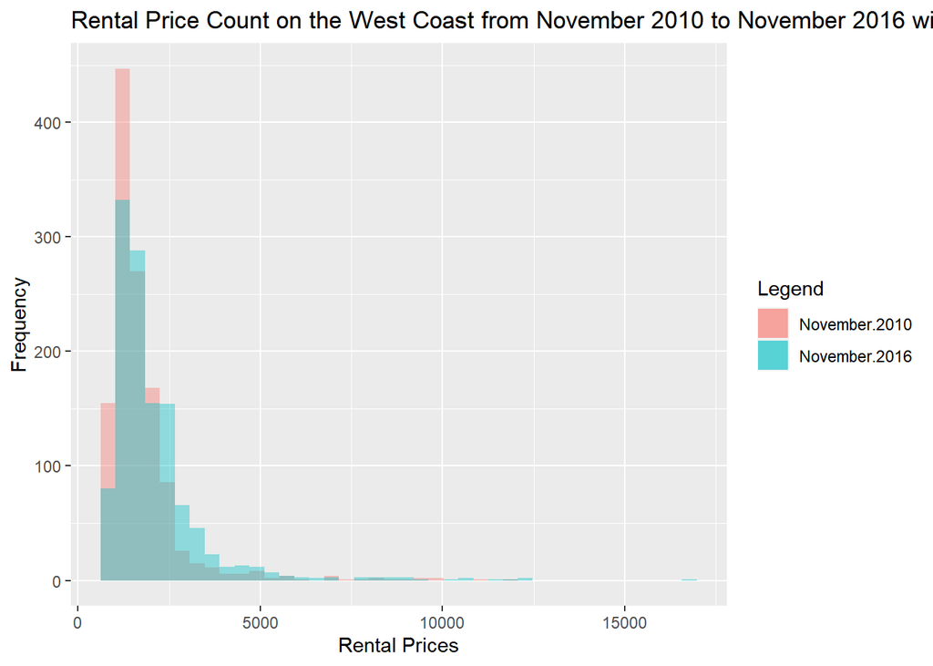

```r
library(ggplot2)

colors <- c("November.2010" = "red", "November.2016" = "blue")

ggplot(westcoast_annual) +
    geom_histogram(aes(November.2010, fill = "November.2010"),alpha = 0.4, bins = 40) +
    geom_histogram(aes(November.2016, fill = "November.2016"),alpha = 0.4, bins = 40) +
    labs(title = "Rental Price Count on the West Coast from November 2010 to November 2016 with Outliers", x = "Rental Prices",
         y = "Frequency", fill = "Legend") +
    scale_color_manual(values = colors)
```

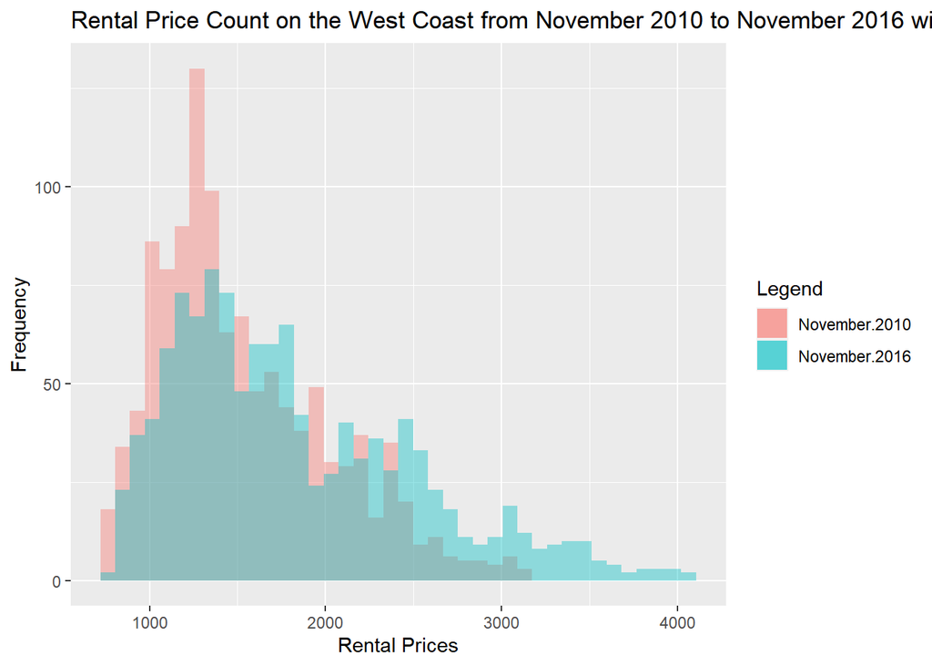

```r
ggplot(westcoast_annualClean) +
    geom_histogram(aes(November.2010, fill = "November.2010"),alpha = 0.4, bins = 40) +
    geom_histogram(aes(November.2016, fill = "November.2016"),alpha = 0.4, bins = 40) +
    labs(title = "Rental Price Count on the West Coast from November 2010 to November 2016 without Outliers", x = "Rental Prices",
         y = "Frequency", fill = "Legend") +
    scale_color_manual(values = colors)
```

The most observed rental price for the West coast for both 2010 and 2016 of November sat right around 1250 a month with the bin shifting slightly to the right for the year 2016 with the number of frequencies being above 100 for 2010 and about 75 for the year 2016. Prices for this region did get more expensive and we can notice that for 2016 the plot is crawling up the x-axis showing that prices are climbing.

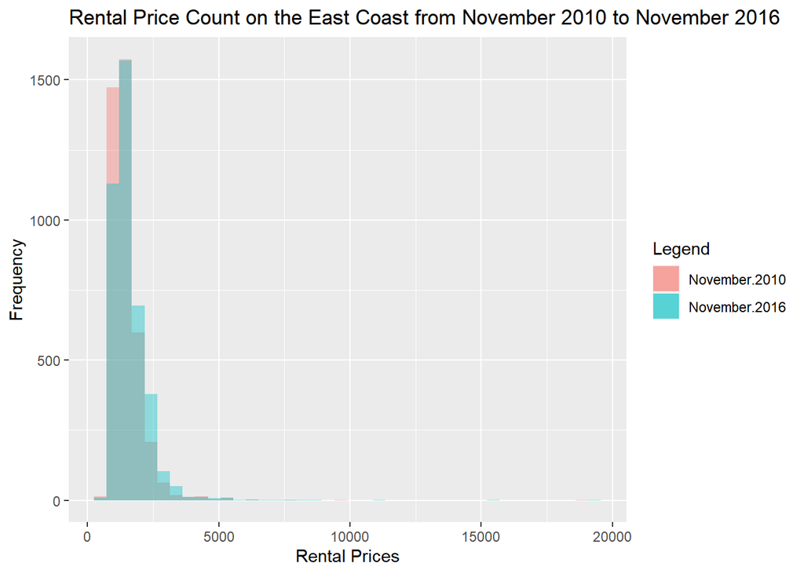

```r
colors <- c("November.2010" = "red", "November.2016" = "blue")

ggplot(eastcoast_annual) +
    geom_histogram(aes(November.2010, fill = "November.2010"),alpha = 0.4, bins = 40) +
    geom_histogram(aes(November.2016, fill = "November.2016"),alpha = 0.4, bins = 40) +
    labs(title = "Rental Price Count on the East Coast from November 2010 to November 2016", x = "Rental Prices",
         y = "Frequency", fill = "Legend") +
    scale_color_manual(values = colors)
```

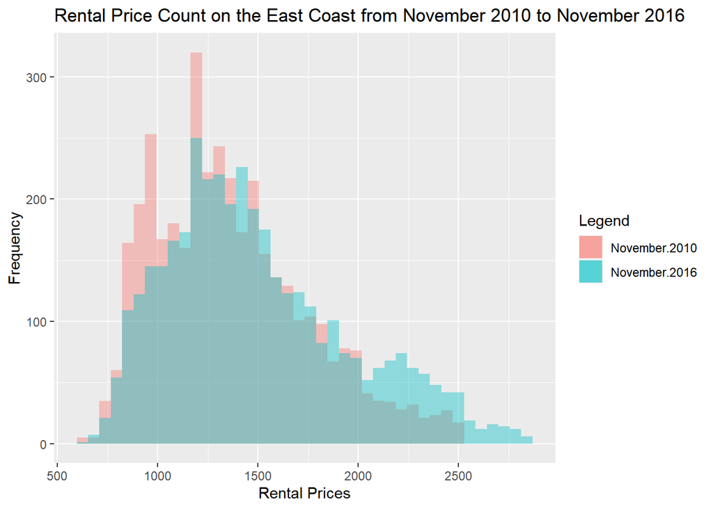

```r
ggplot(eastcoast_annualClean) +
    geom_histogram(aes(November.2010, fill = "November.2010"),alpha = 0.4, bins = 40) +
    geom_histogram(aes(November.2016, fill = "November.2016"),alpha = 0.4, bins = 40) +
    labs(title = "Rental Price Count on the East Coast from November 2010 to November 2016", x = "Rental Prices",
         y = "Frequency", fill = "Legend") +
    scale_color_manual(values = colors)
```

For the East coast, it is clear again that about 1250 a month for the rental price is the most frequent price. Just like with the West coast we see that the blue, depicting the year 2016, is pulling itself up the x-axis again showing climbing rental prices. One thing to note about the East coast plots is the y-axis clearly being a larger number showing just the differences in observations between the two regions.

# Results of Boxplots

### West Coast

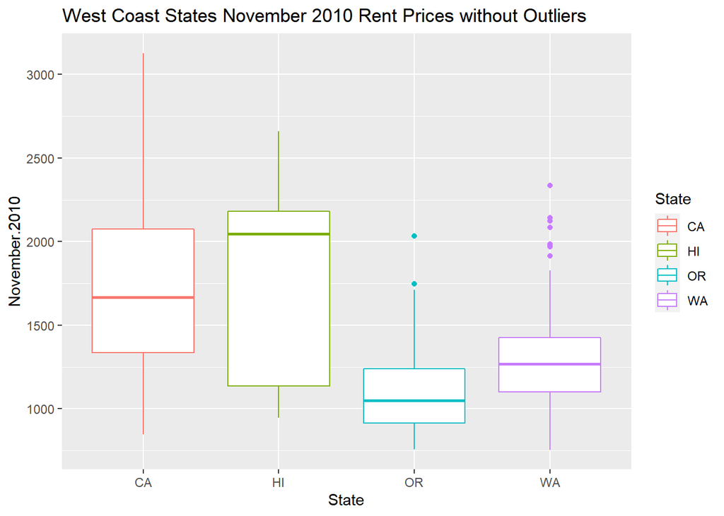

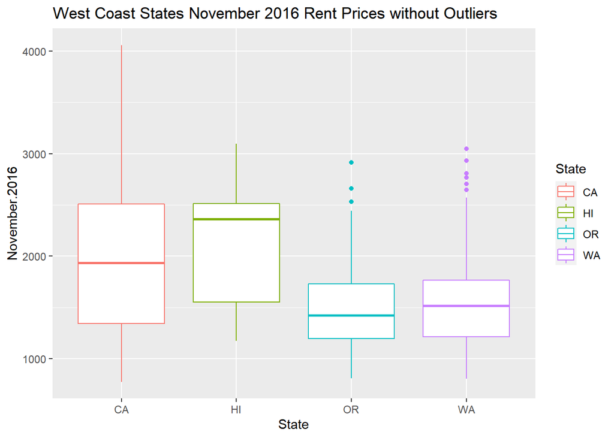

```r
ggplot(westcoast_annualClean, aes(State, November.2010, color=State)) + geom_boxplot()+labs(title = "West Coast States November 2010 Rent Prices without Outliers")
ggplot(westcoast_annualClean, aes(State, November.2016, color=State)) + geom_boxplot()+labs(title = "West Coast States November 2016 Rent Prices without Outliers")
```

### East Coast

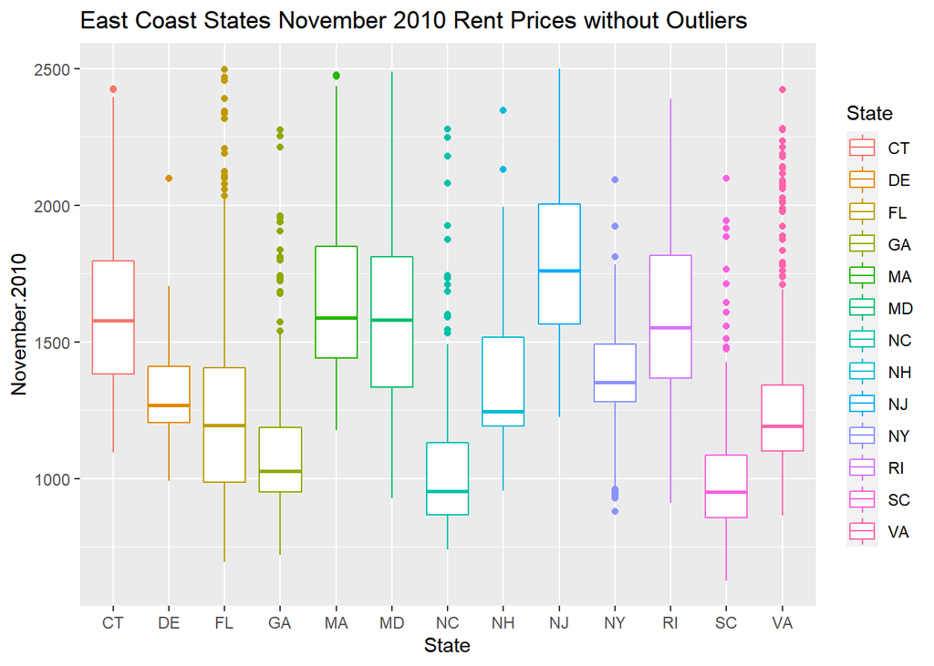

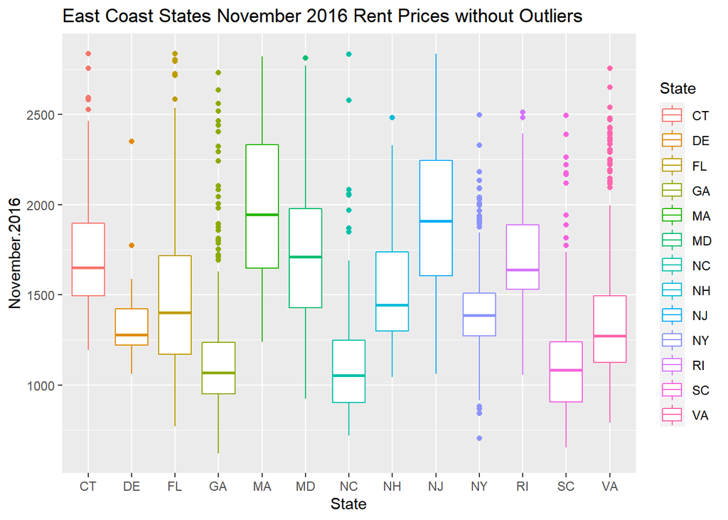

```r
ggplot(eastcoast_annualClean, aes(State, November.2010, color=State)) + geom_boxplot()+labs(title = "East Coast States November 2010 Rent Prices without Outliers")
ggplot(eastcoast_annualClean, aes(State, November.2016, color=State)) + geom_boxplot()+labs(title = "East Coast States November 2016 Rent Prices without Outliers")
```

Clearly after plotting the coasts as a whole region in lieu of the coast’s states that the West coast generally has higher rental prices both on the November 2010 plot and on the November 2016 plot. The average of the West coast monthly rental price on November 2010 is 1534 a month with the interquartile ranging from 1171 to 1834 a month. For the November 2016 plot, the average monthly rental price is 1823 a month with a interquartile range spanning from 1294 to 2272 a month.

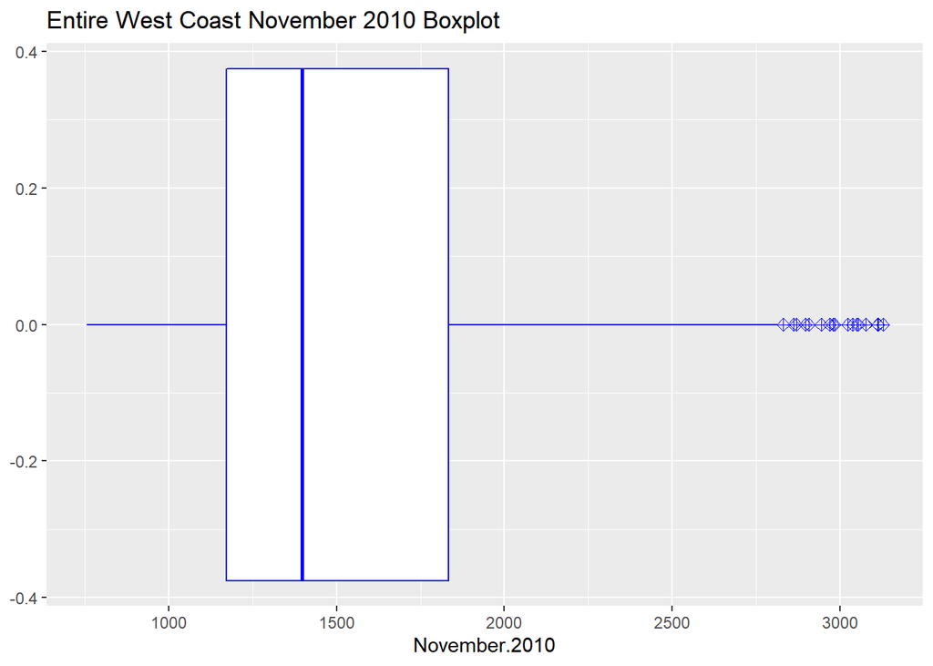

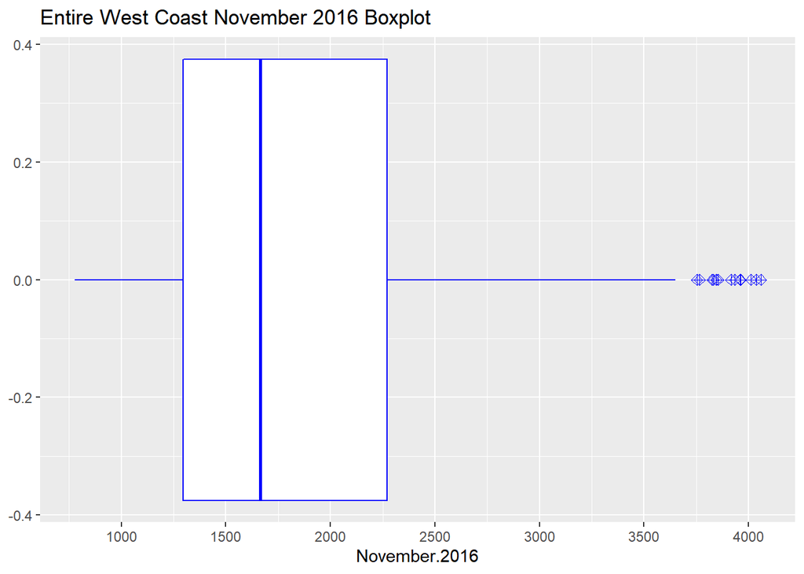

```r
ggplot(westcoast_annualClean, aes(x=November.2010)) + geom_boxplot(color="blue", outlier.shape = 9, outlier.size = 2, outlier.color = "blue") + labs(title="Entire West Coast November 2010 Boxplot") + scale_x_continuous(breaks=seq(500, 4000, 500))
ggplot(westcoast_annualClean, aes(x=November.2016)) + geom_boxplot(color="blue", outlier.shape = 9, outlier.size = 2, outlier.color = "blue") + labs(title="Entire West Coast November 2016 Boxplot") + scale_x_continuous(breaks=seq(500, 4000, 500))
```

It is apparent of the price difference between the two regions with the East coast average monthly rental price on November 2010 being 1370 a month with the interquartile range being 1082 to 1598, considerably lower than the 2010 data from the West coast. For the month of November in 2016 in the East coast the average monthly rent is 1498 with a interquartile range comprising of 1170 to 1765, yet again lower than the West’s 2016 numbers.

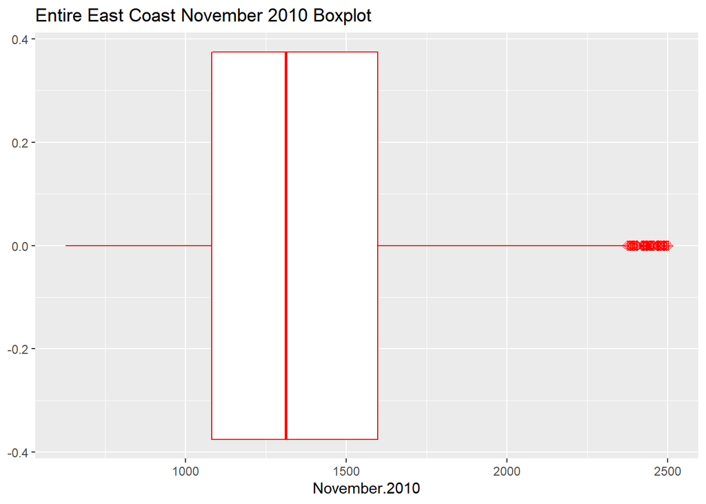

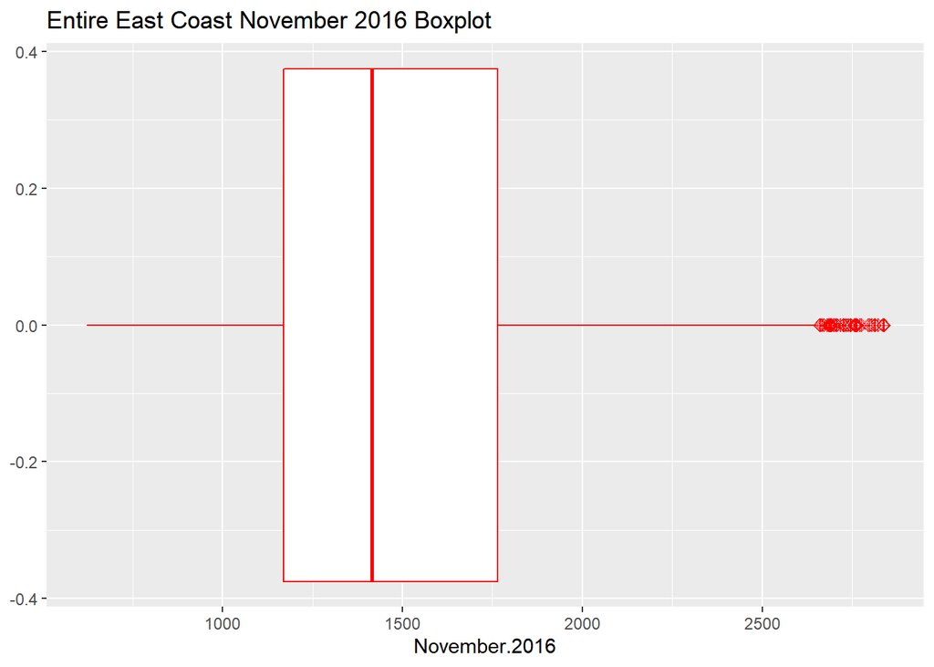

```r
ggplot(eastcoast_annualClean, aes(x=November.2010)) + geom_boxplot(color="red", outlier.shape = 9, outlier.size = 2, outlier.color = "red") + labs(title="Entire East Coast November 2010 Boxplot") + scale_x_continuous(breaks=seq(500, 4000, 500))
ggplot(eastcoast_annualClean, aes(x=November.2016)) + geom_boxplot(color="red", outlier.shape = 9, outlier.size = 2, outlier.color = "red") + labs(title="Entire East Coast November 2016 Boxplot") + scale_x_continuous(breaks=seq(500, 4000, 500))
```

# T-Test Results

Now knowing that the West coast easily coast around 200 to 300 dollars more a month, the last question to answer and to reassure that the West coast region costs more on average is to see if there was ever overlapping in means. This being done by using t-tests on the variables November 2010 and the variable November 2016. The t-test was set at two different intervals one being at 80 and the other being at 99 percent. For the time variable of November 2010 at an 80 percent confidence interval the range spanned from 1515 to 1553 for the West coast and ranged from 1362 to 1378 for the East coast. In 2016, still at 80 percent, the West coast had a range of 1798 to 1849 and the East with a range from 1489 to 1508. When setting the confidence interval at 99 percent the West has a range of 1497 to 1571 for 2010 and 1771 to 1876 for the year 2016. The East coast had a range from 1354 to 1386 for 2010 and a span of 1480 to 1517 for 2016. The results of the t-test endorse the conclusion that the West coast had a higher average monthly rental price and never had overlapping at the 80 or 99 percent confidence interval of the t-tests with their being a differnece again of roughly 200 to 300 dollars a month.

# Cities of Interest

While our dataset looked at all of the city codes in the United States, it also allows us to dig deeper. We picked multiple cities of interest in order to analyze the dataset at a more personal level. Our cities of interest are NYC (Queens) (with only data from December 2011 onwards), LA, PA, Houston (Harris), Chicago (Cook), Dallas, Las Vegas, San Fran, Detroit (Wayne), Roanoke, Richmond, District of Columbia, Baltimore, Seattle(King). We picked these cities off of multiple metrics, their population, their closeness and significance to Virginia and D.C., and their significance in respect to the rent/housing events in the time period of 2011 to 2017.

### Data Gathering and Possible Biases, Original Analytics

The information was gathered from the Zillow database of more than 100 million homes at the time. The data points are median terms given for each month over the time period and attributed to each city code. This can be a cause of bias when we are trying to look at the total population of rent prices over the United States, as first of all, city codes do not evenly represent the entire US. Because the data is only from Zillow, it may under or over represent some areas, or give misleading points, depending on how commonly Zillow is used in those areas. Likewise, the dataset of medians is derived from a machine learning algorithm, which can have its own errors. Because this dataset is showing the median values over time, the analysis of median vs mean as the better center of measure in the context of rent prices has most likely already been completed on the data compiler’s side. This indicates that the original data set had already calculated the measures of centers along the time frame for us.

### NYC and Missing Data

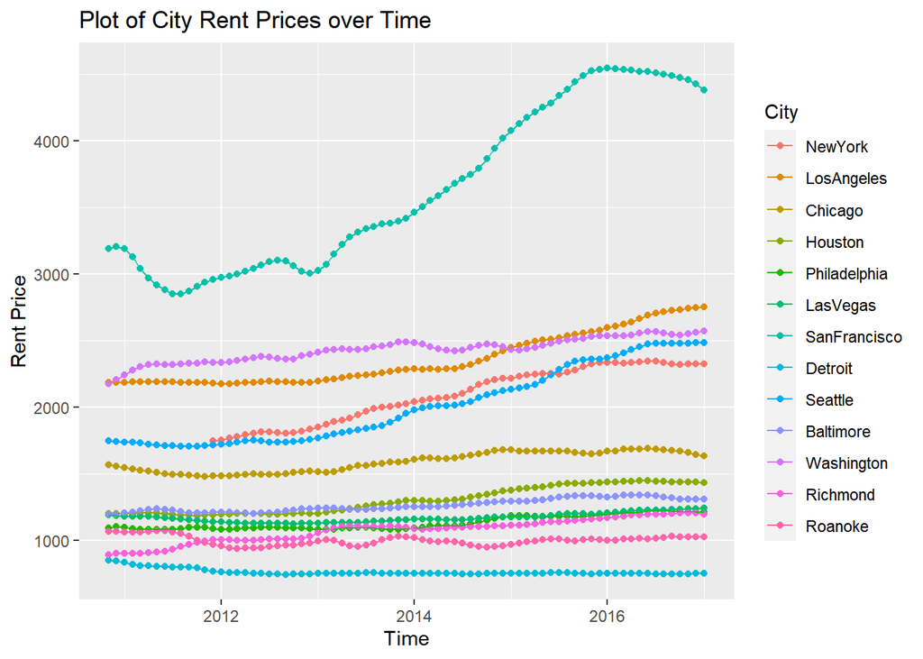

```r
ggplot(zillow_melt, aes(x=Date, y=Prices, group=City, color=City, na.rm=TRUE)) + geom_point() + geom_line() + labs(x="Time", y="Rent Price", title="Plot of City Rent Prices over Time")
```

### Detroit, in the Context of Our Problem and in Time

On the other hand, cities like Detroit and San Francisco were also selected for their significance at the time. Detroit went through the largest municipal bankruptcy ever seen in the United States in 2013 (Davey & Walsh, 2013). With an estimated debt between 18 and 20 billion dollars, the city had been steadily shrinking in population since the 20th century, and parts of the city became abandoned. Due to these facts, it was expected that the median would fall over time from 2011 to 2017. This was somewhat verified by the time series plots themselves, as Detroit would consistently be at the bottom of the graphs.

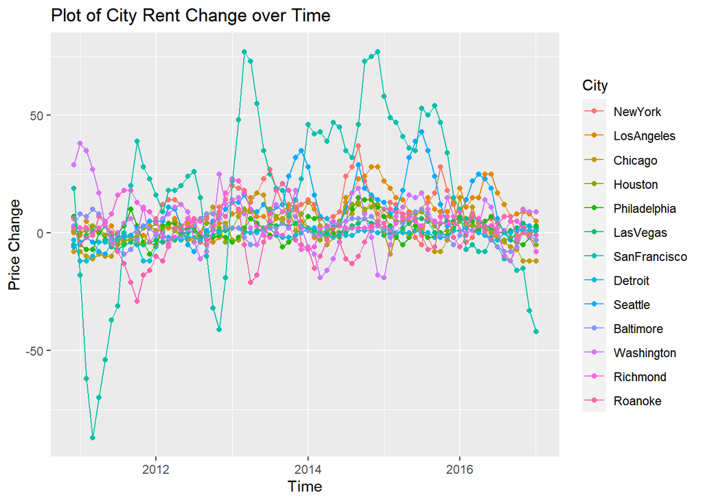

```r
zillow_cmelt <- melt(zillow_change, id = "Date")
names(zillow_cmelt)[2] <- "City"
names(zillow_cmelt)[3] <- "PriceChange"
ggplot(zillow_cmelt, aes(x=Date, y=PriceChange, group=City, color=City, na.rm=TRUE)) + geom_point() + geom_line() + labs(x="Time", y="Price Change", title="Plot of City Rent Change over Time")
```

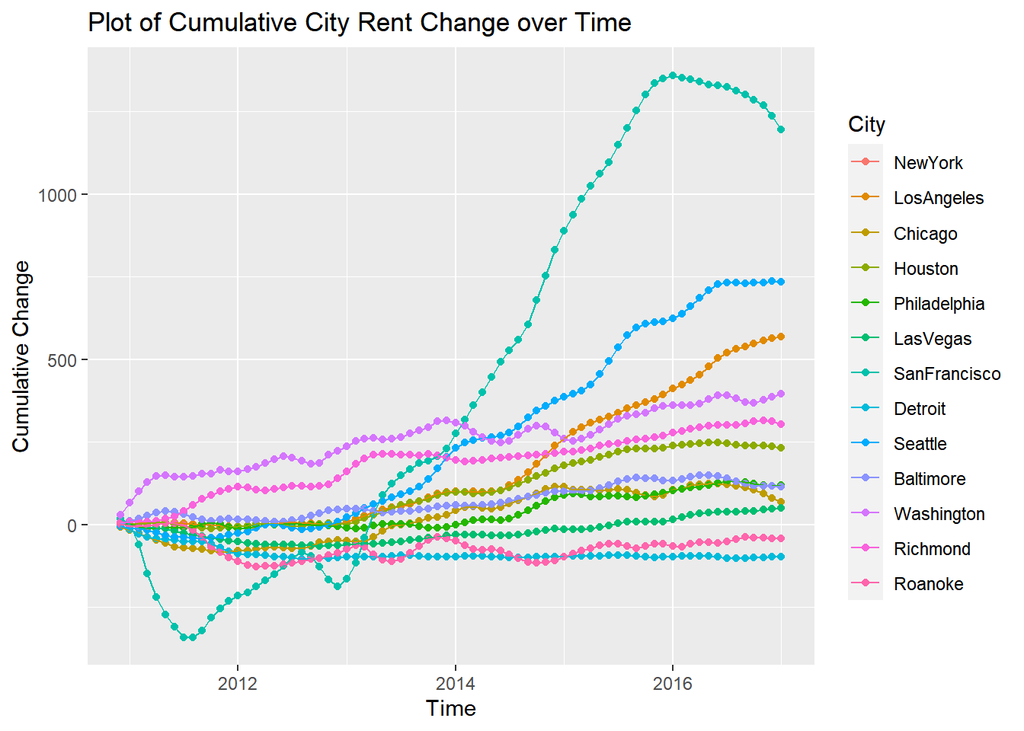

```r
zillow_cumumelt <- melt(zillow_cumulative, id = "Date")
names(zillow_cumumelt)[2] <- "City"
names(zillow_cumumelt)[3] <- "CumulativePriceChange"
ggplot(zillow_cumumelt, aes(x=Date, y=CumulativePriceChange, group=City, color=City, na.rm=TRUE)) + geom_point() + geom_line() + labs(x="Time", y="Cumulative Change", title="Plot of Cumulative City Rent Change over Time")
```